# Sjogren Syndrome - ITC on TESAE

- Show All Code
- Hide All Code
- View Source

Author

Ananda Biswas

Published

September 17, 2026

## Required Packages

**Show/Hide Code**

```r
library(openxlsx)
library(gt)
library(gemtc)
library(rjags)
library(tidyverse)
```

## Loading Data

**Show/Hide Code**

```r
df0 <- read.xlsx("Safety_Outcomes.xlsx", sheet = "TESAE")
```

**Show/Hide Code**

```r
df1 <- data.frame(study = df0$STUDY,
                  treatment = df0$TREATMENT,
                  responders = df0$N.EVENT,
                  sampleSize = df0$N)
# column names MUST be these

df1 |> gt()
```

| study | treatment | responders | sampleSize |
| --- | --- | --- | --- |
| Xu 2025 | Telitacicept_160mg | 11 | 127 |
| Xu 2025 | Placebo | 10 | 127 |
| Neptunus | VAY736QM | 21 | 305 |
| Neptunus | Placebo | 30 | 307 |

## Creating the Network

**Show/Hide Code**

```r
network <- mtc.network(data.ab = df1)
```

**Show/Hide Code**

```r
summary(network)
```

```
$Description
[1] "MTC dataset: Network"

$`Studies per treatment`
           Placebo Telitacicept_160mg           VAY736QM
                 2                  1                  1

$`Number of n-arm studies`
2-arm
    2

$`Studies per treatment comparison`
       t1                 t2 nr
1 Placebo Telitacicept_160mg  1
2 Placebo           VAY736QM  1
```

## Network Diagram

**Show/Hide Code**

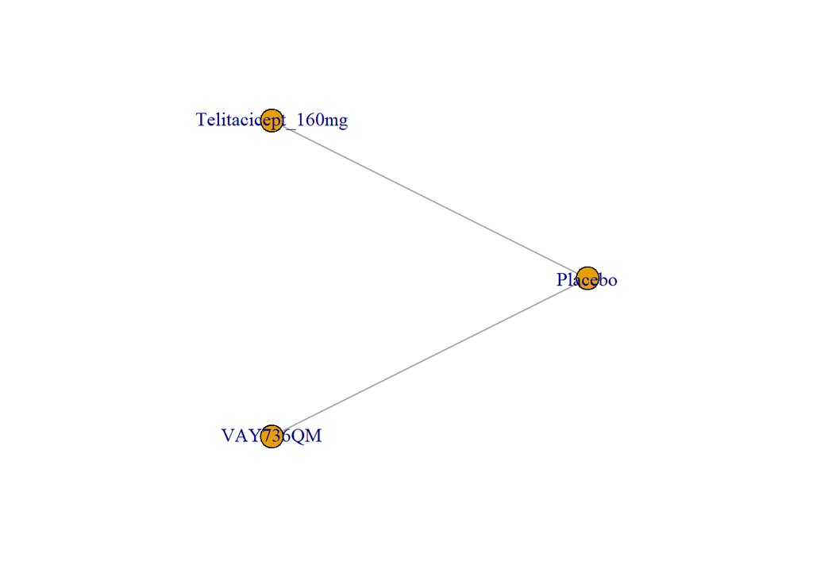

```r
plot(network)
```

## Model Fitting

### Building the NMA Model

`mtc.model()` generates random numbers using the R functions. Therefore, `set.seed()` is called before calling `mtc.model()`.

**Show/Hide Code**

```r
set.seed(14)
```

**Show/Hide Code**

```r
model <- mtc.model(network,
                   likelihood = "binom",
                   link = "log",
                   linearModel = "fixed",
                   om.scale = NULL,
                   n.chain = 4)
```

`om.scale` stands for Outcome Magnitude scale and it is used to set the width of essentially every “vague” prior in the model. Prior to heterogeneity parameter is set to `dunif(0, om.scale)` and priors of the treatment effects are set to `N(0, sd = 15 * om.scale)`.

### Running MCMC

Before calling `mtc.run()`, the random number generator type and seed are set for each of the chains. Refer to [gemtc::mtc.model documentation](https://cran.r-project.org/web/packages/gemtc/refman/gemtc.html#mtc.model) for more.

**Show/Hide Code**

```r
seeds <- sample.int(4, n = .Machine$integer.max)

model$inits <- mapply(c, model$inits, list(
  list(.RNG.name="base::Wichmann-Hill", .RNG.seed=seeds[1]),
  list(.RNG.name="base::Marsaglia-Multicarry", .RNG.seed=seeds[2]),
  list(.RNG.name="base::Super-Duper", .RNG.seed=seeds[3]),
  list(.RNG.name="base::Mersenne-Twister", .RNG.seed=seeds[4])),
  SIMPLIFY=FALSE)
```

Wichmann-Hill, Marsaglia-Multicarry etc. are the names of different pseudo-random number generator (PRNG) algorithms built into JAGS. JAGS needs each MCMC chain to use an independent stream of random numbers, so it ships with several distinct generator algorithms - a different one is assigned to each chain so their random draws don’t overlap or correlate.

**Show/Hide Code**

```r
results <- mtc.run(model,
                   n.adapt = 5000,
                   n.iter  = 20000)
```

### Assessing MCMC Convergence

**Show/Hide Code**

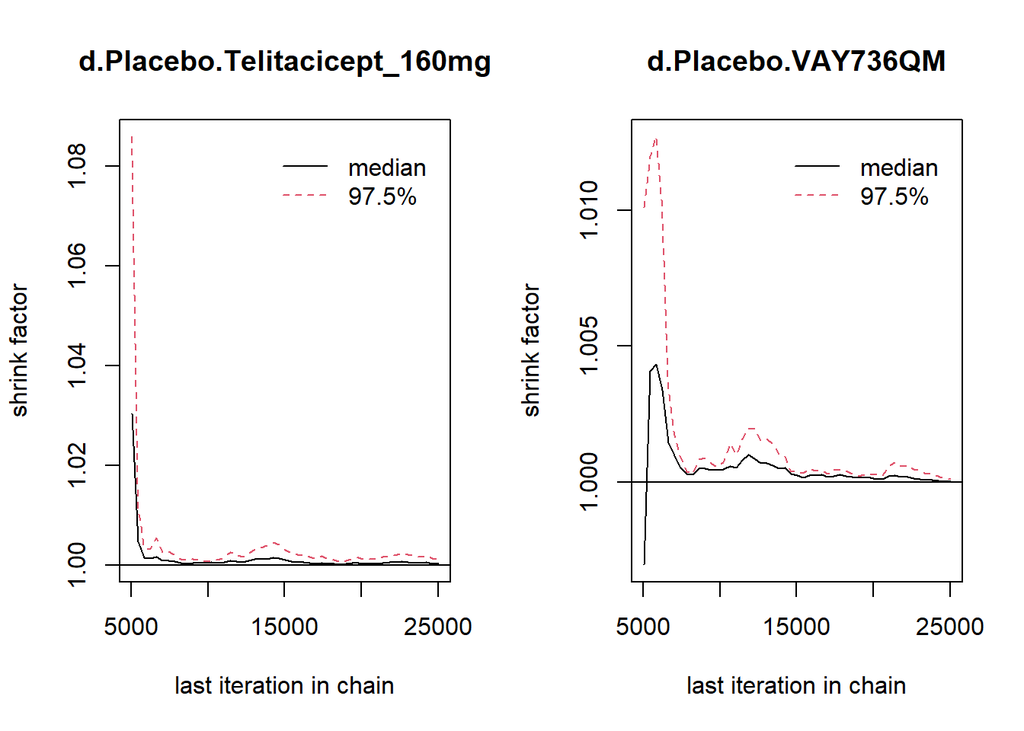

```r
gelman.plot(results)
```

From the plots, we can be assured of convergence.

## Posterior Summaries

**Show/Hide Code**

```r
summary(results)
```

```
Results on the Log Risk Ratio scale

Iterations = 5001:25000
Thinning interval = 1
Number of chains = 4
Sample size per chain = 20000

1. Empirical mean and standard deviation for each variable,
   plus standard error of the mean:

                                Mean     SD  Naive SE Time-series SE
d.Placebo.Telitacicept_160mg  0.0933 0.4276 0.0015120       0.003516
d.Placebo.VAY736QM           -0.3580 0.2749 0.0009719       0.001908

2. Quantiles for each variable:

                                2.5%     25%      50%     75%  97.5%
d.Placebo.Telitacicept_160mg -0.7514 -0.1913  0.09375  0.3782 0.9283
d.Placebo.VAY736QM           -0.9057 -0.5423 -0.35450 -0.1714 0.1742

-- Model fit (residual deviance):

    Dbar       pD      DIC
3.993958 3.992705 7.986664

4 data points, ratio 0.9985, I^2 = 25%
```

## Relative Effects

**Show/Hide Code**

```r
Relative.Effects <- relative.effect.table(results)
Relative.Effects
```

```
Log Risk Ratio (95% CrI)

         Placebo           0.09375 (-0.7514, 0.9283)  -0.3545 (-0.9057, 0.1742)
-0.09375 (-0.9283, 0.7514)     Telitacicept_160mg      -0.4517 (-1.446, 0.5428)
 0.3545 (-0.1742, 0.9057)   0.4517 (-0.5428, 1.446)            VAY736QM
```

The above results are in log-RR scale. Let us have them in RR scale.

**Show/Hide Code**

```r
exp(Relative.Effects)
```

```
Log Risk Ratio (95% CrI)

       Placebo          1.098 (0.4717, 2.53)  0.7015 (0.4043, 1.19)
0.9105 (0.3952, 2.12)    Telitacicept_160mg   0.6365 (0.2355, 1.721)
1.425 (0.8401, 2.474)  1.571 (0.5811, 4.247)         VAY736QM
```

## Final Result

Extract the necessary information.

**Show/Hide Code**

```r
RR.array <- exp(Relative.Effects)

get_comparison <- function(arr, new_drug, reference) {
  data.frame(
    Comparison = paste(new_drug, "vs.", reference),
    RR = round(arr[reference, new_drug, "50%"], 2),
    Lower = round(arr[reference, new_drug, "2.5%"], 2),
    Upper = round(arr[reference, new_drug, "97.5%"], 2)
  )
}

RR_table <- rbind(
  get_comparison(RR.array, "VAY736QM", "Placebo"),
  get_comparison(RR.array, "Telitacicept_160mg", "Placebo"),
  get_comparison(RR.array, "VAY736QM", "Telitacicept_160mg")
)

rownames(RR_table) <- NULL
```

**Show/Hide Code**

```r
data.frame(RR_table) |> gt()
```

| Comparison | RR | Lower | Upper |
| --- | --- | --- | --- |
| VAY736QM vs. Placebo | 0.70 | 0.40 | 1.19 |
| Telitacicept_160mg vs. Placebo | 1.10 | 0.47 | 2.53 |
| VAY736QM vs. Telitacicept_160mg | 0.64 | 0.24 | 1.72 |

## Forest Plot

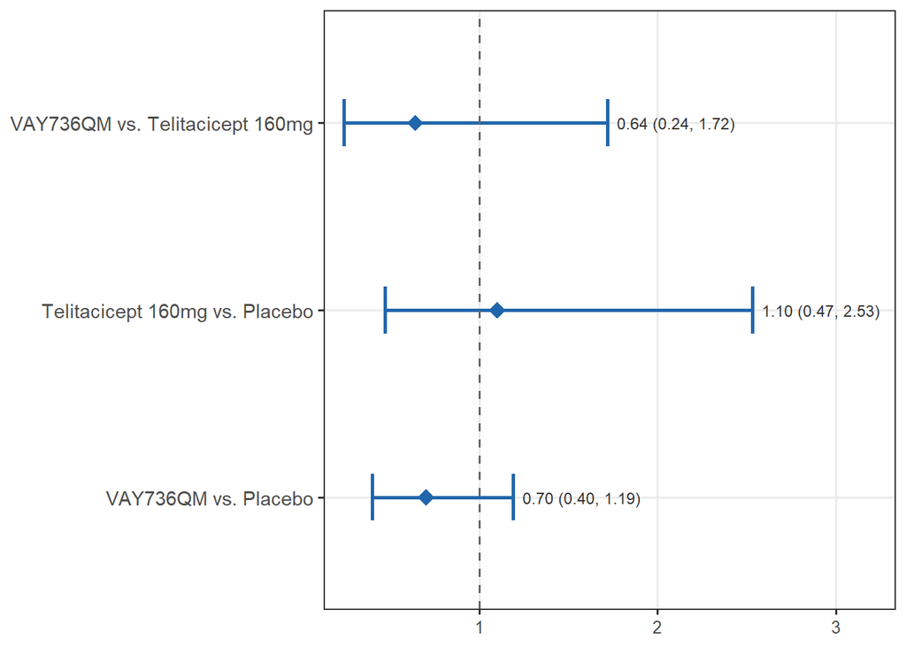